# Factor Variables

Econometrics - ECON 426

## Indicator variables

## Indicator variables

**Indicator variables** allow us to construct models in which some or all regression model parameters, including the intercept, change for some observations in the sample

- Indicator variables are used to account for qualitative factors in econometric models
- They are often called dummy, binary or dichotomous variables, because they take just two values, usually one or zero, to indicate the presence or absence of a characteristic or to indicate whether a condition is true or false
- They are also called dummy variables, to indicate that we are creating a numeric variable for a qualitative, non-numeric characteristic
- We use the terms indicator variable and dummy variable interchangeably

## Indicator variables

We define an indicator variable D as: \[D = \left\{ \matrix{ 1{\rm{ \;\; if\ characteristic\ is\ present}} \hfill \cr 0{\rm{ \;\; if\ characteristic\ is\ not\ present}} \hfill \cr} \right.\]

Adding an indicator variable causes a parallel shift in the relationship

## Indicator variables

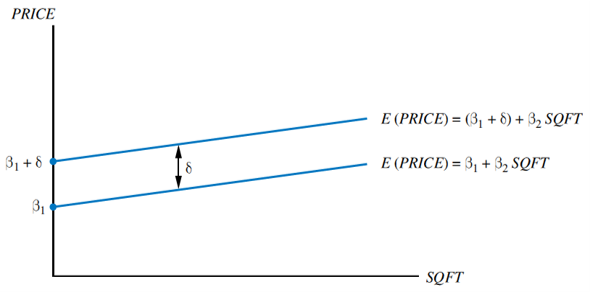

## Indicator variables

- The value D = 0 defines the reference group, or base group
- We could pick any reference group, or base group
- Choose a base group to simplify interpretation

## Slope-indicator or slope dummy variables

- The product of an indicator variable and another independent variable is called an interaction variable
- Alternatively, it is called a *slope-indicator variable* or a *slope dummy variable*, because it allows for a change in the slope of the relationship

## Example: Home Prices

Consider the model \[PRICE = {{\rm{\beta }}_1} + \delta D + {{\rm{\beta }}_2}SQFT + e\]

Then we have \[E\left( {PRICE} \right) = \left\{ \matrix{ \left( {{{\rm{\beta }}_1} + \delta } \right) + {{\rm{\beta }}_2}SQFT{\rm{\; when\ }}D = 1 \hfill \cr {{\rm{\beta }}_1} + {{\rm{\beta }}_2}SQFT{\rm{\;when\ }}D = 0 \hfill \cr} \right.\]

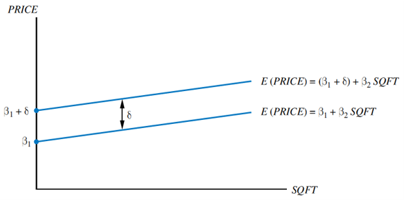

## Example: Home Prices

Consider the model \[PRICE = {{\rm{\beta }}_1} + {\rm{\delta }}D + {{\rm{\beta }}_2}SQFT + {\rm{\gamma }}\left( {SQFT \times D} \right) + e\]

Then we have \[E\left( {PRICE} \right) = \left\{ \matrix{ \left( {{{\rm{\beta }}_1} + {\rm{\delta }}} \right) + \left( {{{\rm{\beta }}_2} + {\rm{\gamma }}} \right)SQFT{\rm{\;when\ }}D{\rm{ }} = {\rm{ }}1 \hfill \cr {{\rm{\beta }}_1} + {{\rm{\beta }}_2}SQFT{\rm{\;when\ }}D{\rm{ }} = {\rm{ }}0{\rm{ }} \hfill \cr} \right.\]

## Example: Home Prices

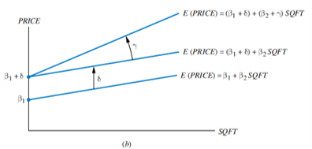

## Example: Home Prices

```r
data("utown", package="PoEdata")
mod1 <- lm(price~sqft,data=utown)
mod2 <- lm(price~sqft+utown,data=utown)
mod3 <- lm(price~sqft*utown,data=utown)
export_summs(mod1,mod2,mod3,digits=3)
```

```
          ------------------------------------------------------------
                               Model 1        Model 2        Model 3
                        ----------------------------------------------
            (Intercept)     30.920 ***      5.681         23.063 ***
                            (9.337)        (4.290)        (6.239)
            sqft             8.597 ***      8.356 ***      7.664 ***
                            (0.368)        (0.168)        (0.247)
            utown                          60.369 ***     28.124 ***
                                           (0.983)        (8.511)
            sqft:utown                                     1.280 ***
                                                          (0.335)
                        ----------------------------------------------
            N             1000           1000           1000
            R2               0.354          0.865          0.867
          ------------------------------------------------------------
            *** p < 0.001; ** p < 0.01; * p < 0.05.

Column names: names, Model 1, Model 2, Model 3
```

## Example: Home Prices

The slope can be expressed as: \[{{\partial E\left( {PRICE} \right)} \over {\partial SQFT}} = \left\{ \matrix{ {{\rm{\beta }}_2} + {\rm{\gamma \;when\ }}D = 1 \hfill \cr {{\rm{\beta }}_2}{\rm{\;when\ }}D = 0 \hfill \cr} \right.\]

```r
library(multcomp)
mod.lh <- glht(mod3,
    linfct = c(
      "(Intercept) = 0",
      "sqft = 0",
      "(Intercept) + utown = 0",
      "sqft + sqft:utown = 0"
    )
  )
```

## Example: Home Prices

```r
summary(mod.lh)
```

```
     Simultaneous Tests for General Linear Hypotheses

Fit: lm(formula = price ~ sqft * utown, data = utown)

Linear Hypotheses:
                         Estimate Std. Error t value Pr(>|t|)
(Intercept) == 0          23.0625     6.2392   3.696   <0.001 ***
sqft == 0                  7.6642     0.2466  31.079   <0.001 ***
(Intercept) + utown == 0  51.1860     5.7881   8.843   <0.001 ***
sqft + sqft:utown == 0     8.9437     0.2274  39.325   <0.001 ***
---
Signif. codes:  0 '***' 0.001 '**' 0.01 '*' 0.05 '.' 0.1 ' ' 1
(Adjusted p values reported -- single-step method)
```

## Example: Home Prices

```r
confint(mod.lh, level=0.95)
```

```
     Simultaneous Confidence Intervals

Fit: lm(formula = price ~ sqft * utown, data = utown)

Quantile = 2.2851
95% family-wise confidence level


Linear Hypotheses:
                         Estimate lwr     upr
(Intercept) == 0         23.0625   8.8055 37.3196
sqft == 0                 7.6642   7.1007  8.2278
(Intercept) + utown == 0 51.1860  37.9597 64.4124
sqft + sqft:utown == 0    8.9437   8.4240  9.4634
```

## Factor Variables

## Factor Variables

- In R, an indicator variable is called factor, category, or ennumerated type and there is no distinction between binary (such as yes-no, or male-female) or multiple-category factors.
- R automatically creates dummy variables for each category within a factor variable and excludes a (baseline) category from a model.
- The choice of the baseline category, as well as which categories should be included can be changed using the function `relevel()`

## Example: Home Prices

```r
mod3 <- lm(price~sqft*utown,data=utown)
mod4 <- lm(price~sqft*relevel(as.factor(utown),ref=2),data=utown)
export_summs(mod3,mod4,digits=4)
```

```
          -----------------------------------------------------------
                                            Model 1         Model 2
                                    ---------------------------------
            (Intercept)                 23.0625 ***     51.1860 ***
                                        (6.2392)        (5.7881)
            sqft                         7.6642 ***      8.9437 ***
                                        (0.2466)        (0.2274)
            utown                       28.1235 ***
                                        (8.5106)
            sqft:utown                   1.2795 ***
                                        (0.3355)
            relevel(as.factor(utown                    -28.1235 ***
            ),
            ref = 2)0
                                                        (8.5106)
            sqft:relevel(as.factor(                     -1.2795 ***
            utown),
            ref = 2)0
                                                        (0.3355)
                                    ---------------------------------
            N                         1000            1000
            R2                           0.8669          0.8669
          -----------------------------------------------------------
            *** p < 0.001; ** p < 0.01; * p < 0.05.

Column names: names, Model 1, Model 2
```

## You did it!